# Project Python Foundations: FoodHub Data Analysis

**Marks: 60**

### Context

The number of restaurants in New York is increasing day by day. Lots of students and busy professionals rely on those restaurants due to their hectic lifestyles. Online food delivery service is a great option for them. It provides them with good food from their favorite restaurants. A food aggregator company FoodHub offers access to multiple restaurants through a single smartphone app.

The app allows the restaurants to receive a direct online order from a customer. The app assigns a delivery person from the company to pick up the order after it is confirmed by the restaurant. The delivery person then uses the map to reach the restaurant and waits for the food package. Once the food package is handed over to the delivery person, he/she confirms the pick-up in the app and travels to the customer's location to deliver the food. The delivery person confirms the drop-off in the app after delivering the food package to the customer. The customer can rate the order in the app. The food aggregator earns money by collecting a fixed margin of the delivery order from the restaurants.

### Objective

The food aggregator company has stored the data of the different orders made by the registered customers in their online portal. They want to analyze the data to get a fair idea about the demand of different restaurants which will help them in enhancing their customer experience. Suppose you are hired as a Data Scientist in this company and the Data Science team has shared some of the key questions that need to be answered. Perform the data analysis to find answers to these questions that will help the company to improve the business.

### Data Description

The data contains the different data related to a food order. The detailed data dictionary is given below.

### Data Dictionary

- order_id: Unique ID of the order
- customer_id: ID of the customer who ordered the food
- restaurant_name: Name of the restaurant
- cuisine_type: Cuisine ordered by the customer
- cost: Cost of the order
- day_of_the_week: Indicates whether the order is placed on a weekday or weekend (The weekday is from Monday to Friday and the weekend is Saturday and Sunday)
- rating: Rating given by the customer out of 5
- food_preparation_time: Time (in minutes) taken by the restaurant to prepare the food. This is calculated by taking the difference between the timestamps of the restaurant's order confirmation and the delivery person's pick-up confirmation.
- delivery_time: Time (in minutes) taken by the delivery person to deliver the food package. This is calculated by taking the difference between the timestamps of the delivery person's pick-up confirmation and drop-off information

### Let us start by importing the required libraries

```python
# import libraries for data manipulation
import numpy as np
import pandas as pd

# import libraries for data visualization
import matplotlib.pyplot as plt
import seaborn as sns
```

### Understanding the structure of the data

```python
# uncomment and run the following lines for Google Colab
# from google.colab import drive
# drive.mount('/content/drive')
```

```python
# read the data
df = pd.read_csv('foodhub_order.csv')
# returns the first 5 rows
df.head()
```

|  | order_id | customer_id | restaurant_name | cuisine_type | cost_of_the_order | day_of_the_week | rating | food_preparation_time | delivery_time |
| --- | --- | --- | --- | --- | --- | --- | --- | --- | --- |
| 0 | 1477147 | 337525 | Hangawi | Korean | 30.75 | Weekend | Not given | 25 | 20 |
| 1 | 1477685 | 358141 | Blue Ribbon Sushi Izakaya | Japanese | 12.08 | Weekend | Not given | 25 | 23 |
| 2 | 1477070 | 66393 | Cafe Habana | Mexican | 12.23 | Weekday | 5 | 23 | 28 |
| 3 | 1477334 | 106968 | Blue Ribbon Fried Chicken | American | 29.20 | Weekend | 3 | 25 | 15 |
| 4 | 1478249 | 76942 | Dirty Bird to Go | American | 11.59 | Weekday | 4 | 25 | 24 |

#### Observations:

The DataFrame has 9 columns as mentioned in the Data Dictionary. Data in each row corresponds to the order placed by a customer.

### **Question 1:** How many rows and columns are present in the data? [0.5 mark]

```python
# Write your code here
df.shape  #The shape function in the Pandas library returns the number of rows and columns in the mentioned dataset.
```

```
(1898, 9)
```

#### Observations:

There are 1,898 rows and 9 columns in the FoodHub dataset.

### **Question 2:** What are the datatypes of the different columns in the dataset? (The info() function can be used) [0.5 mark]

```python
# Use info() to print a concise summary of the DataFrame
df.info()  #The info() function in the Pandas library will return the number of non-null values for each column in the mentioned dataset, along with the datatype of each column.
```

```
<class 'pandas.core.frame.DataFrame'>
RangeIndex: 1898 entries, 0 to 1897
Data columns (total 9 columns):
 #   Column                 Non-Null Count  Dtype
---  ------                 --------------  -----
 0   order_id               1898 non-null   int64
 1   customer_id            1898 non-null   int64
 2   restaurant_name        1898 non-null   object
 3   cuisine_type           1898 non-null   object
 4   cost_of_the_order      1898 non-null   float64
 5   day_of_the_week        1898 non-null   object
 6   rating                 1898 non-null   object
 7   food_preparation_time  1898 non-null   int64
 8   delivery_time          1898 non-null   int64
dtypes: float64(1), int64(4), object(4)
memory usage: 133.6+ KB
```

#### Observations:

- order_id and customer_id are integers, and it makes sense because they are numerical variables.
- restaurant_name and cuisine_type are both objects, and they are categorical variables.
- cost_of_the_order is a float, and since most payments have decimal values, it is best to keep this column as a float datatype.
- day_of_the_week is an object and a categorical variable.
- Although the rating values are numbers, rating is an object datatype because it is seen as a categorical variable in this dataset, and will not be analyzed in a numerical perspective.
- food_preparation_time and delivery_time are both integers and they are numerical variables, since they are representing the number of minutes.
- Since non-null count is the same as the number of rows in each column, there are no empty values in this FoodHub dataset.

### **Question 3:** Are there any missing values in the data? If yes, treat them using an appropriate method. [1 mark]

```python
# Write your code here
df.isnull().sum() #The isnull() function in Pandas shows whether each entry in the columns is null or not by displaying true or false.
#By adding the sum function, we can see the sum of the null values in each column.
```

```
order_id                 0
customer_id              0
restaurant_name          0
cuisine_type             0
cost_of_the_order        0
day_of_the_week          0
rating                   0
food_preparation_time    0
delivery_time            0
dtype: int64
```

#### Observations:

- The sum of null values in each column is equal to 0. There are no missing values in this FoodHub dataset.
- In the previous .head() function (before question 1), it can be seen that some ratings have a 'Not given' value, which is not necessarily a null value. However, for this situation, taking them as missing values and imputing them with the mode or dropping them can possibly distort the data. It is best to just leave them as they are, and consider them as part of a 'Not given' catergory in the ratings column.

### **Question 4:** Check the statistical summary of the data. What is the minimum, average, and maximum time it takes for food to be prepared once an order is placed? [2 marks]

```python
# Write your code here
df.describe() #The .describe() function in Pandas displays a statistical summary of the numerical columns in the dataset.
#If categorical data should also be present, include='all' can be added in the parenthesis.
```

|  | order_id | customer_id | cost_of_the_order | food_preparation_time | delivery_time |
| --- | --- | --- | --- | --- | --- |
| count | 1.898000e+03 | 1898.000000 | 1898.000000 | 1898.000000 | 1898.000000 |
| mean | 1.477496e+06 | 171168.478398 | 16.498851 | 27.371970 | 24.161749 |
| std | 5.480497e+02 | 113698.139743 | 7.483812 | 4.632481 | 4.972637 |
| min | 1.476547e+06 | 1311.000000 | 4.470000 | 20.000000 | 15.000000 |
| 25% | 1.477021e+06 | 77787.750000 | 12.080000 | 23.000000 | 20.000000 |
| 50% | 1.477496e+06 | 128600.000000 | 14.140000 | 27.000000 | 25.000000 |
| 75% | 1.477970e+06 | 270525.000000 | 22.297500 | 31.000000 | 28.000000 |
| max | 1.478444e+06 | 405334.000000 | 35.410000 | 35.000000 | 33.000000 |

#### Observations:

- After an order is placed, it takes a minimum of 20 minutes for food to be prepared.
- The average food preparation time is 27.37 minutes.
- The maximum food preparation time is 35 minutes.

### **Question 5:** How many orders are not rated? [1 mark]

```python
# Write the code here
(df['rating'] == 'Not given').sum() #(df['rating'] == 'Not given') refers to the values in the rating column that are 'Not given'.
#The .sum() function is used to get the total number of ratings that are 'Not given'.
```

```
736
```

#### Observations:

There are 736 orders that have not been rated.

### Exploratory Data Analysis (EDA)

### **Question 6:** Explore all the variables and provide observations on their distributions. (Generally, histograms, boxplots, countplots, etc. are used for univariate exploration.) [9 marks]

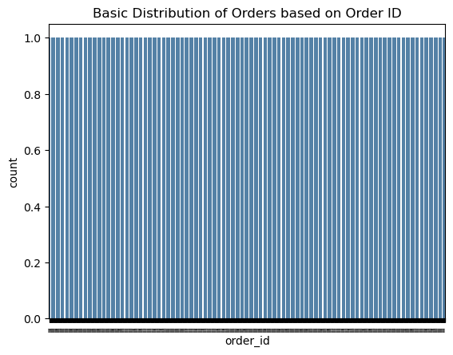

```python
# Write the code here
#order_id countplot (bar graph) - categorical variable
#seaborn .countplot() function
sns.countplot(data=df,x='order_id',color='steelblue'); #creates a bar graph with data from the saved FoodHub info in the df variable, and places order_id on the x-axis(color of the bars is set to steel blue)
plt.xticks(rotation=90, size=1); #x-axis labels are rotated 90 degrees and label size is set to 1 to avoid too much overlap
plt.title('Basic Distribution of Orders based on Order ID'); #.title() function is used to set title of bar graph
plt.show(); #.show() function is used to display bar graph
#.x-ticks(), .title() and .show() functions are from the Pyplot subset of the matplotlib library
```

#### Observations (Order ID):

- There is only one observation for each order_id, so order_id contains a unique value. Each order_id is not related to more than one order.
- There are too many x-axis values for all of the order_id information to be displayed on the graph. This is just a basic overview.

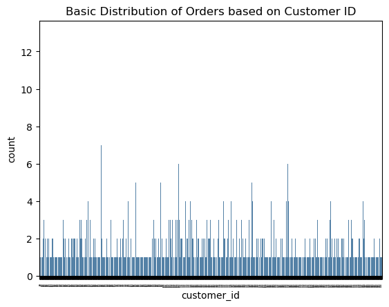

```python
#customer_id countplot (bar graph) - categorical variable
#seaborn .countplot() function
sns.countplot(data=df,x='customer_id',color='steelblue'); #creates bar graph with FoodHub data stored in the df dataframe, placing customer_id on the x-axis(color of the bars is set to steel blue)
plt.xticks(rotation=90,size=1);#x-axis labels are rotated 90 degrees and label size is set to 1 to avoid as much overlap as possible
plt.title('Basic Distribution of Orders based on Customer ID'); #.title() function is used to set title of the bar graph
plt.show(); #.show() function is used to display bar graph
```

#### Observations (Customer ID):

- There seem to be many customers who have only placed one order, because there are more bars at count 1 than at any other count.
- There are customers who have placed more than one order.
- Not all orders are showing up on the graph because there are too many x-axis values for that to be possible. This is just a basic overview.

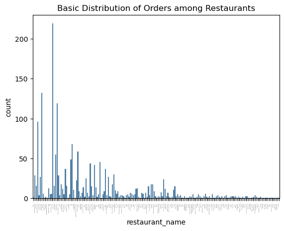

```python
import warnings #importing warnings to filter a Glyph 140 and Glyph 142 warning that keeps reappearing with this particular graph
warnings.filterwarnings('ignore'); #ignoring the warning that keeps reappearing for this plot
#restaurant_name countplot (bar graph) - categorical variable
#seaborn .countplot() function
sns.countplot(data=df,x='restaurant_name',color='steelblue'); #creates bar graph using FoodHub data stored in the df dataframe, and places restaurant_name on the x-axis(color of the bars is set to steel blue)
plt.xticks(rotation=90,size=1); #x-axis labels are rotated 90 degrees and label size is set to 1 to avoid too much overlap of the variables
plt.title('Basic Distribution of Orders among Restaurants');#.title() function is used to set the title for the bar graph
plt.show();#.show() function is used to display the bar graph
```

#### Observations (Restaurant Name):

- The highest number of orders from a restaurant is over 200.
- The lowest number of orders from a restaurant seems to be less than 10.
- The number of orders highly varies among different restaurants.
- This is just a basic overview of the distribution of orders among the restaurants.

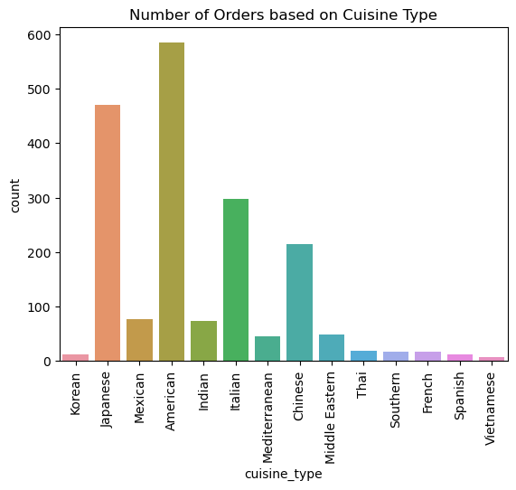

```python
#cuisine_type countplot (bar graph) - categorical variable
#seaborn .countplot() function
sns.countplot(data=df,x='cuisine_type'); #creates bar graph using FoodHub data stored in the df dataframe, and places cuisine_type on the x-axis
plt.xticks(rotation=90); #x-axis labels are rotated 90 degrees to avoid overlapping of labels
plt.title('Number of Orders based on Cuisine Type');#.title() function is used to set the title of the bar graph
plt.show()#.show() function is used to display the bar graph
```

#### Observations (Cuisine Type):

- The cuisine type with the highest number of orders is American.
- The cuisine type with the lowest number of orders is Vietnamese.
- Japanese cuisine type has the second highest number of orders.

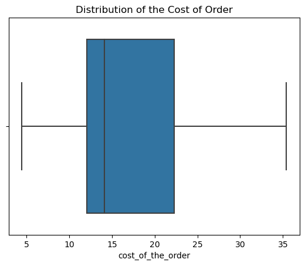

```python
#cost_of_the_order boxplot - numerical variable
#seaborn .boxplot() function
sns.boxplot(data=df,x='cost_of_the_order'); #creates boxplot using FoodHub data stored in df dataframe, and places cost_of_the_order on the x-axis
plt.title('Distribution of the Cost of Order'); #.title() function is used to set the title of the boxplot
plt.show();#.show() function is used to display the boxplot
```

#### Observations (Cost of the Order):

- The distribution of the cost of order is right-skewed because the left whisker is shorter. The median is closer to the left end.
- There seem to be no outliers in the cost_of_the_order column.
- The minimum value is around 5, and the maximum value is around 35.
- 25% of the orders seem to cost 12 or less.
- The median is around 14. 50% of the orders seem to cost 14 or less.
- 75% of the orders seem to cost 23 or less.

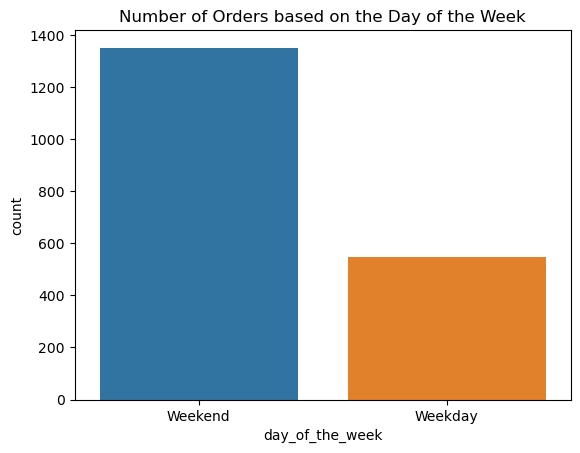

```python
#day_of_the_week countplot (bar graph) - categorical variable
#seaborn .countplot() function
sns.countplot(data=df,x='day_of_the_week'); #creates bar graph using FoodHub data stored in the df dataframe, and places day_of_the_week on the x-axis
plt.title('Number of Orders based on the Day of the Week');#.title() function is used to set the title of the bar graph
plt.show(); #.show() function is used to display the bar graph
```

#### Observations (Day of the Week):

- There are more orders that are on a weekend than on a weekday.
- The number of orders that are on a weekend are more than double the number of orders that are on a weekday.

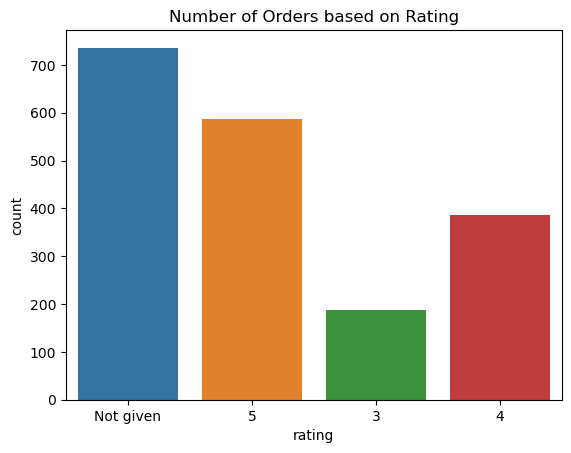

```python
#rating countplot (bar graph) - categorical variable
#seaborn .countplot() function
sns.countplot(data=df,x='rating'); #creates bar graph using FoodHub data stored in the df dataframe, and places rating on the x-axis
plt.title('Number of Orders based on Rating');#.title() function is used to set the title for the bar graph
plt.show();#.show() function is used to display the bar graph
```

#### Observations (Rating):

- The ratings for more than 700 orders are 'Not given'.
- Keeping aside the ratings that have not been given, rating 5 has the highest number of orders, and rating 4 has the second highest.
- Ratings 1 and 2 are not even present in the bar graph, so all of the orders, where rating has been given, have a rating of 3 or higher.

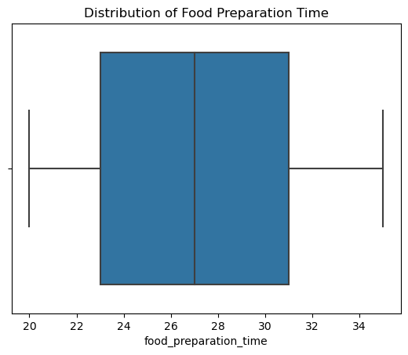

```python
#food_preparation_time boxplot - numerical variable
#seaborn .boxplot() function
sns.boxplot(data=df,x='food_preparation_time'); #creates boxplot using FoodHub data stored in the df dataframe,and places food_preparation_time on the x-axis
plt.title('Distribution of Food Preparation Time');#.title() function used to set the title of the boxplot
plt.show();#.show() function used to display the boxplot
```

#### Observations (Food Preparation Time):

- The boxplot is very slightly right-skewed because the right-whisker is longer. The median is closer to the left end.
- There seem to be no outliers in the food_preparation_time column.
- The median food preparation time is 27. 50% of the orders took 27 minutes or less to be prepared.
- The minimum food preparation time is 20 minutes, and the maximum food preparation time is 35 minutes.
- 25% of the orders took 23 minutes or less to be prepared.
- 75% of the orders took 31 minutes or less to be prepared.

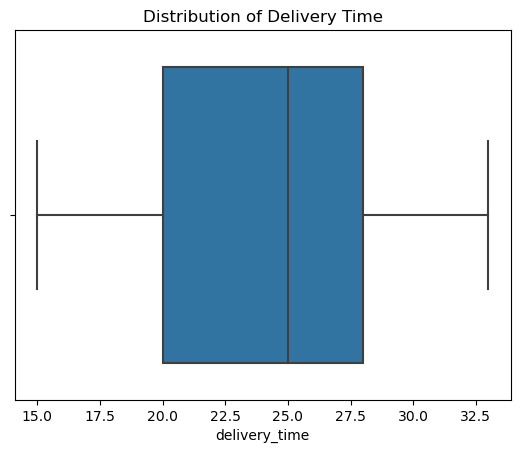

```python
#delivery_time boxplot - numerical variable
#seaborn .boxplot() function
sns.boxplot(data=df,x='delivery_time'); #creates boxplot using FoodHub data stored in the df dataframe, and places delivery_time on the x-axis
plt.title('Distribution of Delivery Time');#.title() function used to set the title of the boxplot
plt.show();#.show() function used to display the boxplot
```

### **Question 7**: Which are the top 5 restaurants in terms of the number of orders received? [1 mark]

```python
# Write the code here
df.groupby(by=['restaurant_name'])['restaurant_name'].count().sort_values(ascending=False)
#The .groupby() function in Pandas organizes the results for specified columns, in this case by restaurant_name(by=['restaurant_name'])
#The restaurant_name are outputted in a list
#The .count() function in Pandas displays the number of times each categorical value in the restaurant_name column is present
#The .sort_values() function in Pandas organizes the list in order of count
#Adding ascending=false in the parenthesis of .sort_values() function sorts values in descending order
```

```
restaurant_name
Shake Shack                  219
The Meatball Shop            132
Blue Ribbon Sushi            119
Blue Ribbon Fried Chicken     96
Parm                          68
                            ...
Klong                          1
Kambi Ramen House              1
Il Bambino                     1
Hunan Manor                    1
Lamarca Pasta                  1
Name: restaurant_name, Length: 178, dtype: int64
```

#### Observations:

- The top 5 restaurants are Shake Shack, The Meatball Shop, Blue Ribbon Sushi, Blue Ribbon Fried Chicken, and Parm.
- Shake Shack received the highest number of orders with 219 orders, and The Meatball Shop received the second highest number of orders with 132 orders.
- Blue Ribbon Sushi received the third highest number of orders with 119 orders, and Blue Ribbon Fried Chicken received the fourth highest number of orders with 96 orders.
- Parm received the fifth highest number of orders with 68 orders.

### **Question 8**: Which is the most popular cuisine on weekends? [1 mark]

```python
# Write the code here
weekend = df[df['day_of_the_week'] == 'Weekend']
weekend.groupby(by=['cuisine_type'])['cuisine_type'].count().sort_values(ascending=False)
#weekend variable is assigned to isolate the df values for just the 'Weekend' values in the day_of_the_week column
#In those weekend values, the data is organized by their cuisine_type (by=['cuisine_type']) using the .groupby() function in Pandas
#Only the values for cuisine type are displayed
#The .count() function in Pandas is used to display the number of times each cuisine_type is observed
#The .sort_values() function in Pandas is used to organize the values in order of count
#Adding ascending=False in the parenthesis of .sort_values() function sorts the values in descending order
```

```
cuisine_type
American          415
Japanese          335
Italian           207
Chinese           163
Mexican            53
Indian             49
Mediterranean      32
Middle Eastern     32
Thai               15
French             13
Korean             11
Southern           11
Spanish            11
Vietnamese          4
Name: cuisine_type, dtype: int64
```

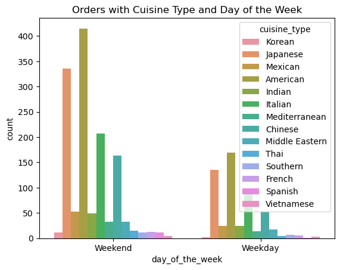

```python
#order count for day of the week, organized by their cuisine type
#seaborn .countplot() function
sns.countplot(data=df,x='day_of_the_week',hue='cuisine_type'); #creates bar graph using FoodHub data stored in df dataframe/places day_of_the_week on the x-axis and colors(hue) represent cuisine type
plt.title('Orders with Cuisine Type and Day of the Week'); #.title() function used to set title of bar graph
plt.show(); #.show() function used to display bar graph
```

#### Observations:

With 415 orders, the most popular cuisine on weekends is American.

### **Question 9**: What percentage of the orders cost more than 20 dollars? [2 marks]

```python
# Write the code here
df[df['cost_of_the_order'] > 20].count()/1898
#A condition is set for the column of cost_of_the_order, where values for cost that are greater than 20 are selected from df
#The .count() function in Pandas displays the count for how many orders reach the condition
#The number from .count() function is divided by 1,898 to get the percentage of orders, because there are a total of 1,898 rows, which represent 1,898 orders
```

```
order_id                 0.292413
customer_id              0.292413
restaurant_name          0.292413
cuisine_type             0.292413
cost_of_the_order        0.292413
day_of_the_week          0.292413
rating                   0.292413
food_preparation_time    0.292413
delivery_time            0.292413
dtype: float64
```

#### Observations:

29.24% of orders cost more than 20 dollars.

### **Question 10**: What is the mean order delivery time? [1 mark]

```python
# Write the code here
df['delivery_time'].mean()
#The delivery_time column values are selected from df
#The .mean() function in Pandas is used to calculate the mean or average from the delivery_time column values.
```

```
24.161749209694417
```

#### Observations:

The mean order delivery time is 24.16 minutes.

### **Question 11:** The company has decided to give 20% discount vouchers to the top 3 most frequent customers. Find the IDs of these customers and the number of orders they placed. [1 mark]

```python
# Write the code here
df.groupby(by=['customer_id'])['customer_id'].count().sort_values(ascending=False)
#The values in df are organized by the customer_id column (by =['customer_id']) using the .groupby() function in Pandas
#The customer_id column values are displayed.
#The .count() function in Pandas is used to count many times each customer_id is seen in this column
#The .sort_values() function in Pandas organizes the count number in order of count
#Adding ascending=False to the parenthesis in .sort_values() displays the results in descending order
```

```
customer_id
52832     13
47440     10
83287      9
250494     8
65009      7
          ..
105903     1
105992     1
106006     1
106324     1
405334     1
Name: customer_id, Length: 1200, dtype: int64
```

#### Observations:

- The IDs of the top 3 most frequent customers are 52832, 47440, and 83287.
- 52832 has placed the highest orders with 13 orders.
- 47440 has placed the second highest orders with 10 orders.
- 83287 has placed the third highest orders with 9 orders.

### **Question 12**: Perform a multivariate analysis to explore relationships between the important variables in the dataset. (It is a good idea to explore relations between numerical variables as well as relations between numerical and categorical variables) [10 marks]

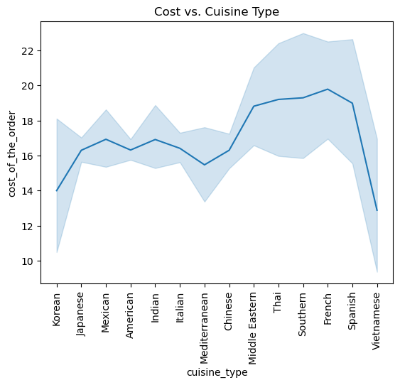

```python
# Write the code here
#cost_of_the_order(numerical variable) vs. cuisine_type(categorical variable)
#seaborn .lineplot() function
sns.lineplot(data=df,x='cuisine_type',y='cost_of_the_order'); #creates lineplot using FoodHub data stored in the df dataframe/places cuisine_type on the x-axis and cost_of_the_order on the y-axis
plt.title('Cost vs. Cuisine Type'); #.title() function used to set title of lineplot
plt.xticks(rotation=90); #.xticks() function used to modify the x-axis labels/rotation= 90 turns them 90 degrees, so that the labels fit well.
plt.show(); #.show() function used to display lineplot
#confidence interval - blue-shaded area (shown by default)
```

#### Observations(Cost vs. Cuisine Type):

- The cost seems to slightly vary, depending on the cuisine type.
- Middle Eastern, Thai, Southern, French, and Spanish have a slightly higher cost than other cuisine types.
- Korean and Vietnamese have a slightly lower cost, compared to other cuisine types.

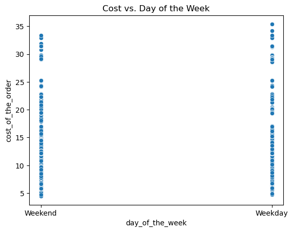

```python
#cost_of_the_order(numerical variable) vs. day_of_the_week(categorical variable)
#seaborn .scatterplot() function
sns.scatterplot(data=df,x='day_of_the_week',y='cost_of_the_order'); #creates scatterplot using FoodHub data stored in df dataframe/places day_of_the_week on the x-axis and cost_of_the_order on the y-axis
plt.title('Cost vs. Day of the Week'); #.title() function used to set title of scatterplot
plt.show(); #.show() function used to display scatterplot
```

#### Observations(Cost vs. Day of the Week):

- There is no specific pattern between cost and day of the week.
- The distribution of cost is very similar on a weekend and on a weekday.

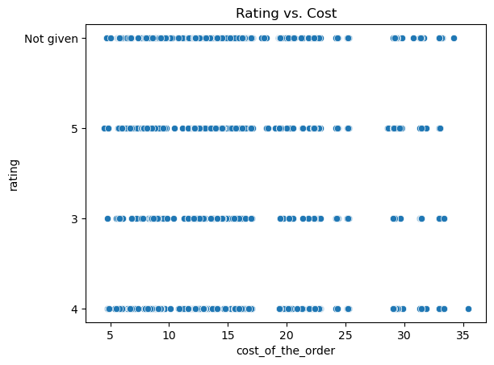

```python
#rating(categorical variable) vs. cost_of_the_order(numerical variable)
#seaborn .scatterplot() function
sns.scatterplot(data=df,x='cost_of_the_order',y='rating'); #creates scatterplot using FoodHub data stored in the df dataframe/places cost_of_the_order on the x-axis and rating on the y-axis
plt.title('Rating vs. Cost'); #.title() function used to set title of scatterplot
plt.show(); #.show() function used to display scatterplot
```

#### Observations (Rating vs.Cost):

- There is no specific pattern between rating and cost.
- Cost of an order does not have a profound effect on rating.

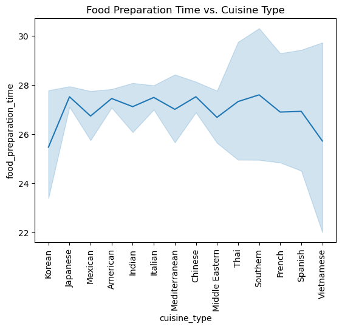

```python
#food_preparation_time(numerical variable) vs. cuisine_type(categorical variable)
#seaborn .lineplot() function
sns.lineplot(data=df,x='cuisine_type',y='food_preparation_time'); #creates lineplot using FoodHub data stored in df dataframe/places cuisine_type on x-axis and food_preparation_time on y-axis
plt.title('Food Preparation Time vs. Cuisine Type'); #.title() function used to set title of lineplot
plt.xticks(rotation=90); #.xticks() function used to modify x-axis labels/rotation=90 rotates the labels 90 degrees to help them fit better
plt.show(); #.show() function used to display lineplot
```

#### Observations (Food Preparation Time vs. Cuisine Type):

- The food preparation time is similar for most cuisines, including Japanese, Mexican, American, Indian, Italian, Mediterranean, Chinese, and Middle Eastern.
- The food preparation time for Korean, Thai, Southern, French, Spanish, and Vietnamese has a wider range. The time for these cusine types is more likely to vary within a wider range.

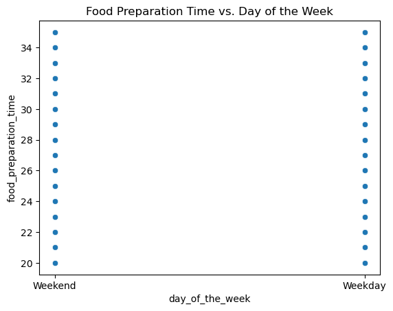

```python
#food_preparation_time(numerical variable) vs. day_of_the_week(categorical variable)
#seaborn .scatterplot() function
sns.scatterplot(data=df,x='day_of_the_week',y='food_preparation_time'); #creates scatterplot using FoodHub data stored in df dataframe/places day_of_the_week on the x-axis and food_preparation_time on the y-axis
plt.title('Food Preparation Time vs. Day of the Week'); #.title() function used to set title of scatterplot
plt.show(); #.show() function used to display scatterplot
```

#### Observations (Food Preparation Time vs. Day of the Week):

- The food preparation time seems to have no pattern with the day of the week.
- Food preparation time is the same on both weekends and weekdays.

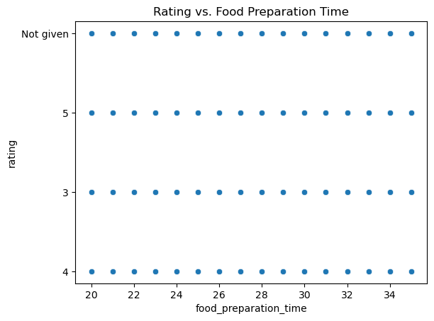

```python
#rating(categorical variable) vs. food_preparation_time(numerical variable)
#seaborn .scatterplot() function
sns.scatterplot(data=df,x='food_preparation_time',y='rating'); #creates scatterplot using FoodHub data stored in the df dataframe/places food_preparation_time on the x-axis and rating on the y-axis
plt.title('Rating vs. Food Preparation Time'); #.title() function used to set title of scatterplot
plt.show(); #.show() function used to display scatterplot
```

#### Observations (Rating vs. Food Preparation Time):

- Rating does not have any specific pattern with food preparation time because each rating category has a similar distribution of the time it took to prepare that order.

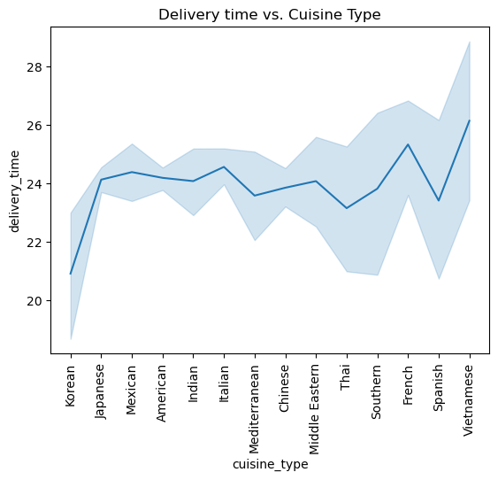

```python
#delivery_time(numerical variable) vs. cuisine_type(catergorical variable)
#seaborn .lineplot() function
sns.lineplot(data=df,x='cuisine_type', y='delivery_time'); #creates lineplot using FoodHub data stored in df dataframe/places cuisine_type on the x-axis and delivery_time on the y-axis
plt.title('Delivery time vs. Cuisine Type'); #.title() function used to set title of lineplot
plt.xticks(rotation=90); #.xticks() function used to modify x-axis labels/rotation=90 rotates the labels 90 degrees
plt.show(); #.show() function used to display lineplot
```

#### Observations (Delivery Time vs. Cuisine Type):

- There does not seem to be a specific pattern between delivery time and cuisine type.
- The ranges for some cuisines vary slightly, especially Korean. Having a lower delivery time can also depend on the restaurants that specialize in this cuisine_type and the location of where the food orders were delivered to.

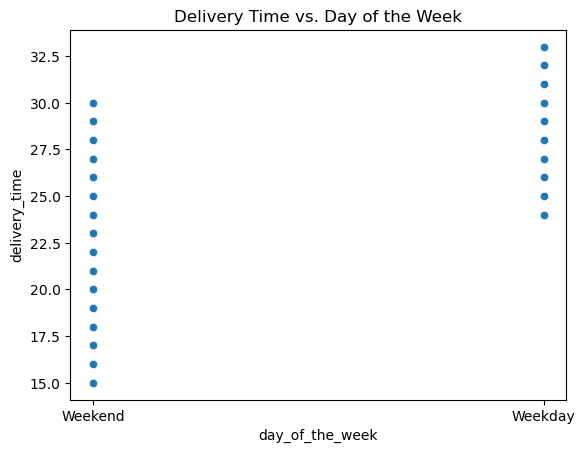

```python
#delivery_time(numerical variable) vs. day_of_the_week(categorical variable)
#seaborn .scatterplot() function
sns.scatterplot(data=df,x='day_of_the_week',y='delivery_time'); #creates scatterplot using FoodHub data stored in the df dataframe/places day_of_the_week on the x-axis and delivery_time on the y-axis
plt.title('Delivery Time vs. Day of the Week') #.title() function used to set title of the scatterplot
plt.show(); #.show() function used to display scatterplot
```

#### Observations (Delivery Time vs. Day of the Week):

- Delivery Time for most orders seems to have a wider range on weekends than on weekdays.
- Most orders on weekdays have a higher delivery time than most orders on weekends.

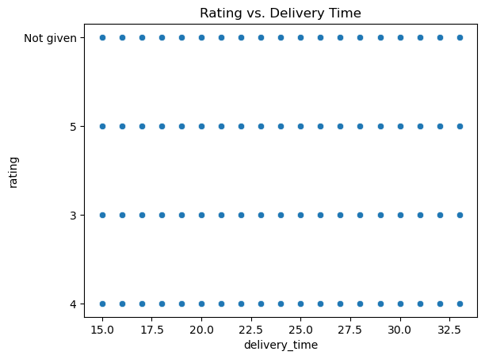

```python
#rating(catergorical variable) vs. delivery_time(numerical variable)
#seaborn .scatterplot() function
sns.scatterplot(data=df,x='delivery_time',y='rating'); #creates scatterplot using FoodHub data stored in df dataframe/places delivery_time on x-axis and rating on y-axis
plt.title('Rating vs. Delivery Time'); #.title() function used to set title of scatterplot
plt.show(); #.show() function used to display scatterplot
```

#### Observations (Rating vs. Delivery Time):

- Rating seems to have no specific pattern with delivery time because the distribution of order delivery time for each rating category is the same.

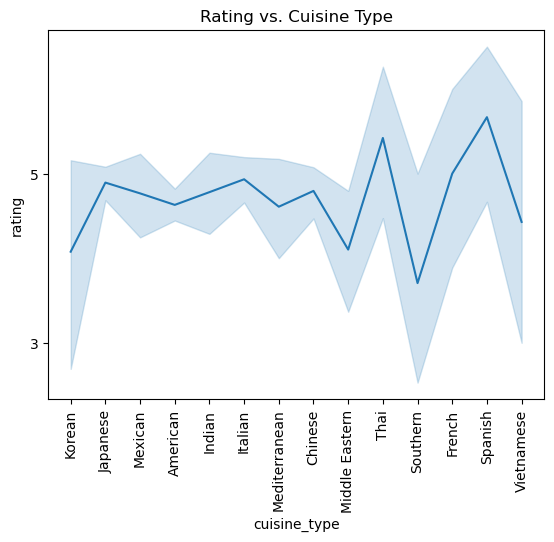

```python
#rating(categorical variable) vs. cuisine_type(categorical variable)
#sebaorn .lineplot() function
sns.lineplot(data=df,x='cuisine_type',y='rating'); #creates lineplot using FoodHub data stored in the df dataframe/places cuisine_type on the x-axis and rating on the y-axis
plt.title('Rating vs. Cuisine Type'); #.title() function used to set title of lineplot
plt.xticks(rotation=90); #.xticks() function used to modify x-axis labels/rotation=90 rotates labels 90 degrees
plt.show() #.show() function used to display lineplot
```

### **Question 13:** The company wants to provide a promotional offer in the advertisement of the restaurants. The condition to get the offer is that the restaurants must have a rating count of more than 50 and the average rating should be greater than 4. Find the restaurants fulfilling the criteria to get the promotional offer. [3 marks]

```python
# Write the code here
df1 = df.copy() #created a copy of the df dataframe and stored it in df1
df1['rating'] = pd.to_numeric(df1['rating'],errors = 'coerce') #.to_numeric() function in Pandas library changes the ratings column in df1 to numeric values(errors='coerce' changes 'Not Given' values to NaN)
rating_mean = df1.groupby(by=['restaurant_name'])['rating'].mean() #.groupby() function in Pandas used to store mean(.mean() function in Pandas) of df1 ratings values based on restaurant_name in a variable called rating_mean
rating_count = df1.groupby(by=['restaurant_name'])['rating'].count() #.groupby() function in Pandas used to store the count(.count() function in Pandas) of df1 ratings values based on restaurant_name in a variable called rating_count
restaurant_ratings = pd.DataFrame({'Mean': rating_mean, 'Count': rating_count})#.DataFrame() function in Pandas used to create dataframe of outputted values stored in rating_mean and rating_count, labeled as Mean and Count columns
restaurant_ratings[restaurant_ratings['Count'] > 50] #restaurant_ratings dataframe is filtered to only show the rows where count is greater than 50.
```

| restaurant_name | Mean | Count |
| --- | --- | --- |
| Blue Ribbon Fried Chicken | 4.328125 | 64 |
| Blue Ribbon Sushi | 4.219178 | 73 |
| Shake Shack | 4.278195 | 133 |
| The Meatball Shop | 4.511905 | 84 |

#### Observations:

- Blue Ribbon Fried Chicken, Blue Ribbon Sushi, Shake Shack, and The Meatball Shop fulfill the criteria to get the promotional offer.
- They have a rating count greater than 50, and the mean for each of these restaurants is also greater than 4.

### **Question 14:** The company charges the restaurant 25% on the orders having cost greater than 20 dollars and 15% on the orders having cost greater than 5 dollars. Find the net revenue generated by the company across all orders. [3 marks]

```python
# Write the code here
df['company_revenue'] = '' #company_revenue column is created in the df dataframe
df['company_revenue'] = np.where(df['cost_of_the_order'] > 20, df['cost_of_the_order'] * 0.25, #using .where() function in NumPy, the first condition is set where 25% charge for orders greater than 20 is added to company_revenue column for each corresponding row
                                np.where(df['cost_of_the_order'] >5, df['cost_of_the_order'] * 0.15,0)) #next condition is set using another .where() function where 15% charge for orders greater than 5 is added to company_revenue column, and if neither condition is met, the company_revenue value for the remaining orders is 0.
df['company_revenue'].sum() #.sum() function in pandas is used to calculate the total value for the company_revenue column
```

```
6166.303
```

#### Observations:

- $6,166.30 is the total revenue generated by the company.

### **Question 15:** The company wants to analyze the total time required to deliver the food. What percentage of orders take more than 60 minutes to get delivered from the time the order is placed? (The food has to be prepared and then delivered.) [2 marks]

```python
# Write the code here
df[df['food_preparation_time'] + df['delivery_time'] > 60].count()/1898 * 100
#food_preparation_time and delivery_time are added together in each row
# .count() function in Pandas is used to count the number of rows where this added time is greater than 60 minutes
#the number of rows(that meet the condition) is divided by 1898 because there are a total of 1898 columns in the df dataframe
#to get the percentage, the number is multiplied by 100
```

```
order_id                 10.537408
customer_id              10.537408
restaurant_name          10.537408
cuisine_type             10.537408
cost_of_the_order        10.537408
day_of_the_week          10.537408
rating                   10.537408
food_preparation_time    10.537408
delivery_time            10.537408
company_revenue          10.537408
dtype: float64
```

#### Observations:

- 10.5% of orders take more than 60 minutes to get delivered once the order is placed.

### **Question 16:** The company wants to analyze the delivery time of the orders on weekdays and weekends. How does the mean delivery time vary during weekdays and weekends? [2 marks]

```python
# Write the code here
print('Weekend Mean:', df[df['day_of_the_week'] == 'Weekend']['delivery_time'].mean())
#'Weekend Mean' string is printed, along with result for delivery_time mean where day_of_the_week in df dataframe is Weekend.
print('Weekday Mean:', df[df['day_of_the_week'] == 'Weekday']['delivery_time'].mean())
#'Weekday Mean' string is printed, along with result for delivery_time mean where day_of_the_week in df dataframe is Weekday.
```

```
Weekend Mean: 22.4700222057735
Weekday Mean: 28.340036563071298
```